### Date: 6 May 2021

### Output: html_document

### Submitted by: Aastha Joshi 20020845001 | Joel Keith Pais 20020845011 | Taksande Sandeep Ravindra 20020845030

### Title: BA Assignment Group 9

### Dataset: Airbags and Accidents

# TASK 1

# Loading and exploring the dataset

```r
file1<-read.csv("C:/Users/Sandeep/Downloads/G9_airbags and accidents (2).csv", stringsAsFactors = FALSE)
str(file1)
```

```
## 'data.frame':    26217 obs. of  18 variables:
##  $ X                    : int  1 2 3 4 5 6 7 8 9 10 ...
##  $ Impact.speed.category: chr  "25-39" "10-24" "10-24" "25-39" ...
##  $ weight               : num  25.1 25.1 32.4 495.4 25.1 ...
##  $ dead                 : chr  "alive" "alive" "alive" "alive" ...
##  $ airbag               : chr  "none" "airbag" "none" "airbag" ...
##  $ seatbelt             : chr  "belted" "belted" "none" "belted" ...
##  $ frontal              : int  1 1 1 1 1 1 1 1 0 1 ...
##  $ sex                  : chr  "f" "f" "f" "f" ...
##  $ ageOFocc             : int  26 72 69 53 32 22 22 32 40 18 ...
##  $ yearacc              : int  1997 1997 1997 1997 1997 1997 1997 1997 1997 1997 ...
##  $ yearVeh              : int  1990 1995 1988 1995 1988 1985 1984 1987 1984 1987 ...
##  $ abcat                : chr  "unavail" "deploy" "unavail" "deploy" ...
##  $ occRole              : chr  "driver" "driver" "driver" "driver" ...
##  $ deploy               : int  0 1 0 1 0 0 0 0 0 0 ...
##  $ injSeverity          : int  3 1 4 1 3 3 3 4 1 0 ...
##  $ caseid               : chr  "2:03:01" "2:03:02" "2:05:01" "2:10:01" ...
##  $ X.1                  : logi  NA NA NA NA NA NA ...
##  $ X.2                  : logi  NA NA NA NA NA NA ...
```

```r
summary(file1)
```

```
##        X         Impact.speed.category     weight             dead
##  Min.   :    1   Length:26217          Min.   :    0.00   Length:26217
##  1st Qu.: 6555   Class :character      1st Qu.:   32.47   Class :character
##  Median :13109   Mode  :character      Median :   86.99   Mode  :character
##  Mean   :13109                         Mean   :  462.81
##  3rd Qu.:19663                         3rd Qu.:  364.72
##  Max.   :26217                         Max.   :57871.60
##
##     airbag            seatbelt            frontal           sex
##  Length:26217       Length:26217       Min.   :0.0000   Length:26217
##  Class :character   Class :character   1st Qu.:0.0000   Class :character
##  Mode  :character   Mode  :character   Median :1.0000   Mode  :character
##                                        Mean   :0.6433
##                                        3rd Qu.:1.0000
##                                        Max.   :1.0000
##
##     ageOFocc        yearacc        yearVeh        abcat
##  Min.   :16.00   Min.   :1997   Min.   :1953   Length:26217
##  1st Qu.:22.00   1st Qu.:1998   1st Qu.:1989   Class :character
##  Median :33.00   Median :2000   Median :1994   Mode  :character
##  Mean   :37.21   Mean   :2000   Mean   :1993
##  3rd Qu.:48.00   3rd Qu.:2001   3rd Qu.:1997
##  Max.   :97.00   Max.   :2002   Max.   :2003
##                                 NA's   :1
##    occRole              deploy       injSeverity       caseid
##  Length:26217       Min.   :0.000   Min.   :0.000   Length:26217
##  Class :character   1st Qu.:0.000   1st Qu.:1.000   Class :character
##  Mode  :character   Median :0.000   Median :2.000   Mode  :character
##                     Mean   :0.337   Mean   :1.716
##                     3rd Qu.:1.000   3rd Qu.:3.000
##                     Max.   :1.000   Max.   :6.000
##                                     NA's   :153
##    X.1            X.2
##  Mode:logical   Mode:logical
##  NA's:26217     NA's:26217
##
##
##
##
##
```

```r
head(file1)
```

```
##   X Impact.speed.category  weight  dead airbag seatbelt frontal sex ageOFocc
## 1 1                 25-39  25.069 alive   none   belted       1   f       26
## 2 2                 10-24  25.069 alive airbag   belted       1   f       72
## 3 3                 10-24  32.379 alive   none     none       1   f       69
## 4 4                 25-39 495.444 alive airbag   belted       1   f       53
## 5 5                 25-39  25.069 alive   none   belted       1   f       32
## 6 6                 40-54  25.069 alive   none   belted       1   f       22
##   yearacc yearVeh   abcat occRole deploy injSeverity  caseid X.1 X.2
## 1    1997    1990 unavail  driver      0           3 2:03:01  NA  NA
## 2    1997    1995  deploy  driver      1           1 2:03:02  NA  NA
## 3    1997    1988 unavail  driver      0           4 2:05:01  NA  NA
## 4    1997    1995  deploy  driver      1           1 2:10:01  NA  NA
## 5    1997    1988 unavail  driver      0           3 2:11:01  NA  NA
## 6    1997    1985 unavail  driver      0           3 2:11:02  NA  NA
```

```r
names(file1)
```

```
##  [1] "X"                     "Impact.speed.category" "weight"
##  [4] "dead"                  "airbag"                "seatbelt"
##  [7] "frontal"               "sex"                   "ageOFocc"
## [10] "yearacc"               "yearVeh"               "abcat"
## [13] "occRole"               "deploy"                "injSeverity"
## [16] "caseid"                "X.1"                   "X.2"
```

# Checking for null and missing values

```r
sum(is.null(file1))
```

```
## [1] 0
```

```r
sum(is.na(file1))
```

```
## [1] 52588
```

```r
df <- na.omit(file1)
sum(is.na(df))
```

```
## [1] 0
```

# Loading required libraries

```r
library(dplyr)
```

```r
library(ggplot2)
library(ggthemes)
```

# Creating a subset of only required columns

```r
df<-file1[, -c(3,16)]
names(df)
```

```
##  [1] "X"                     "Impact.speed.category" "dead"
##  [4] "airbag"                "seatbelt"              "frontal"
##  [7] "sex"                   "ageOFocc"              "yearacc"
## [10] "yearVeh"               "abcat"                 "occRole"
## [13] "deploy"                "injSeverity"           "X.1"
## [16] "X.2"
```

# Renaming columns

```r
df<-rename(df, speed=Impact.speed.category)
```

# TASK 2

# Introduction

#### When it comes to transportation, people’s safety is and always will be our top priority. With the rise of self driving cars, we must re-examine our current safety measures and introduce new ones that will better match the future of driving. While there were many car safety features introduced in the past decades, the airbag is often considered one of the most important piece of safety equipment. However, it is vital to study the situations when airbags are the most effective and what the drawbacks are. Despite the fact that this technology saved numerous lives, there were also accidents when it was a contributing factor to inguries and even fatalities.

#### Let’s begin the research by looking at the trend in the accidents over the years.

# Accidents per year

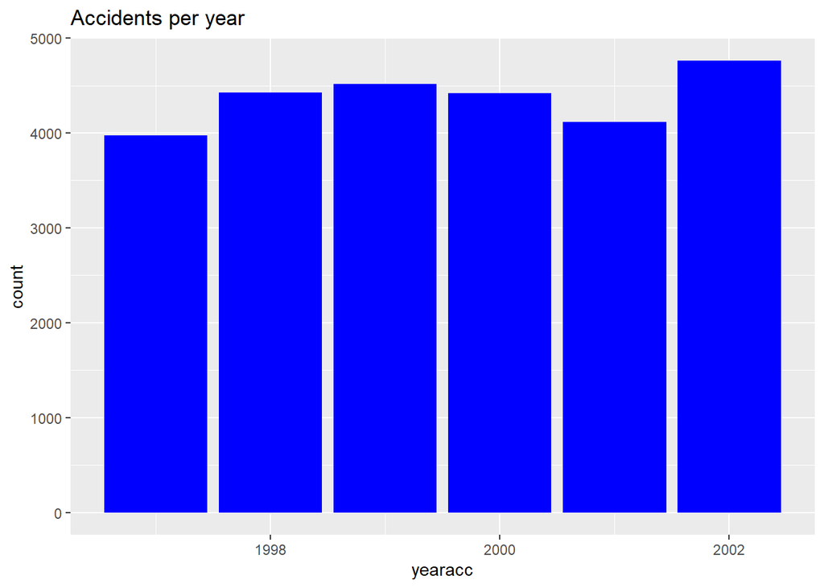

```r
ggplot(df)+aes(x=yearacc)+geom_bar(fill='blue')+ggtitle("Accidents per year")
```

#### The accidents have always been high in number but we can see from the above graph that there was a slight decrease in the number of accidents during 2000 and 2001 but then it again showed an upward trend in 2002.

# Survival rate

```r
total_alive<-sum(df$dead=='alive')
total_alive
```

```
## [1] 25037
```

```r
total_dead<-sum(df$dead=='dead')
total_dead
```

```
## [1] 1180
```

```r
total<-total_alive+total_dead
total
```

```
## [1] 26217
```

```r
survival_rate<-(total_alive/total)
survival_rate<-survival_rate*100
survival_rate
```

```
## [1] 95.4991
```

```r
counts<-table(df$dead,df$yearacc)
counts
```

```
##
##         1997 1998 1999 2000 2001 2002
##   alive 3751 4229 4316 4233 3943 4565
##   dead   224  198  200  187  172  199
```

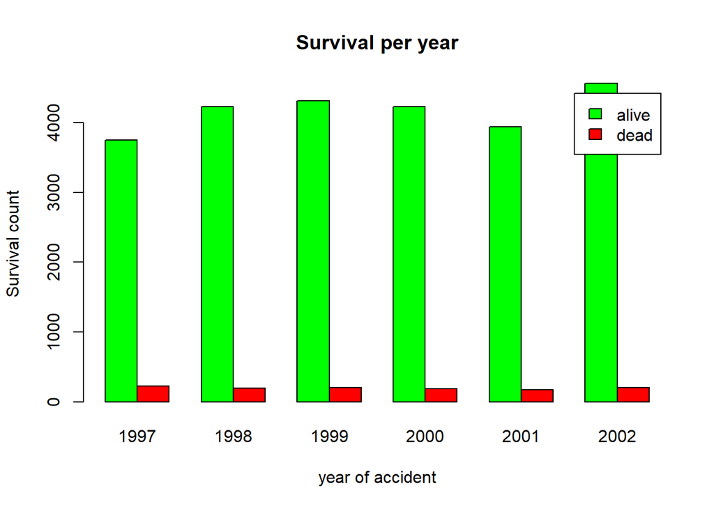

```r
barplot(counts,main = "Survival per year",xlab ="year of accident",ylab = "Survival count",col = c("green","red"),legend=rownames(counts),beside = TRUE)+theme_minimal()
```

#### From our dataset, the total number of people were 26,217 out of which 25,037 were accident survivors while 1,180 succumbed to the injuries. Based on these data, the overall survival rate can be calculated as the ratio of the total number of survivors out of the total people in the dataset i.e 25,037/26,217 = 0.95499 which indicates that there is 95.5% survival rate among the people who met with accidents.

#### Which is a really good percentage when compared to the number of accidents per year.

#### Also, from the graph we can see that the number of survivors are very high even though the number of accidents are high.

# Year of Vehicle Vs Airbags

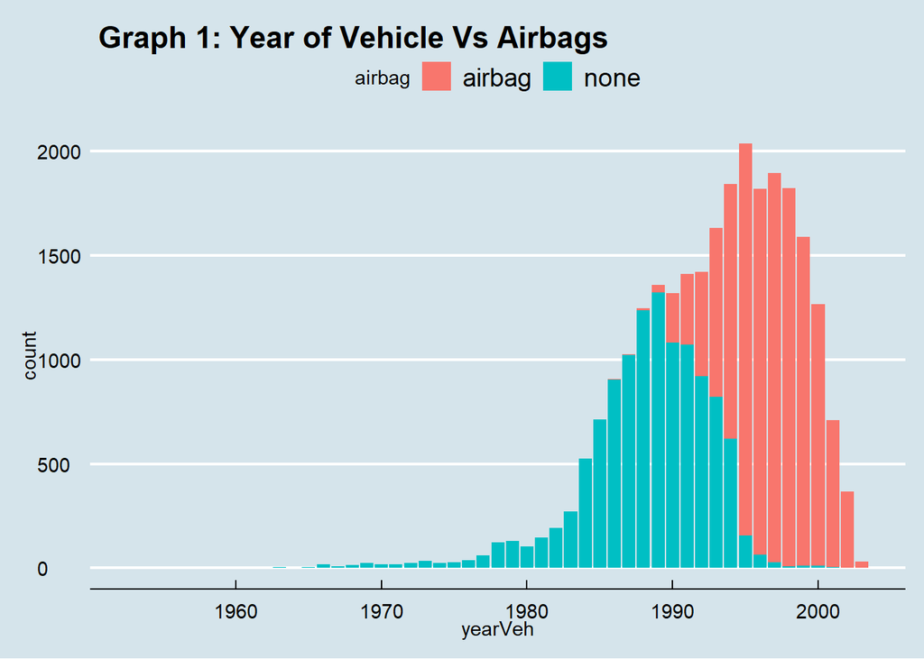

```r
ggplot(data= df)+geom_bar(aes(yearVeh, fill=airbag))+ggtitle(" Graph 1: Year of Vehicle Vs Airbags")+theme_economist()
```

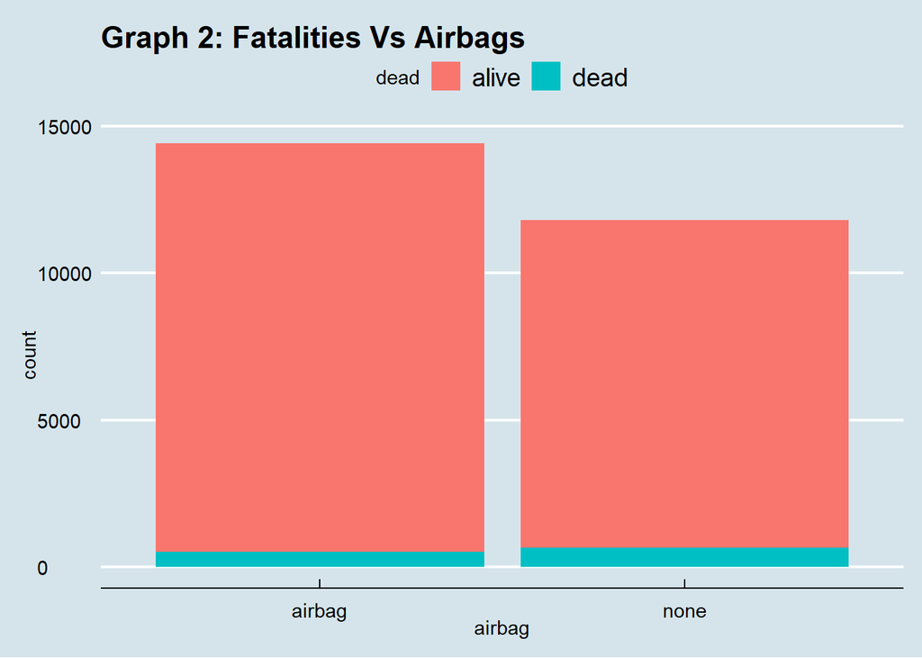

```r
ggplot(data= df)+geom_bar(aes(airbag, fill=dead))+ggtitle("Graph 2: Fatalities Vs Airbags")+theme_economist()
```

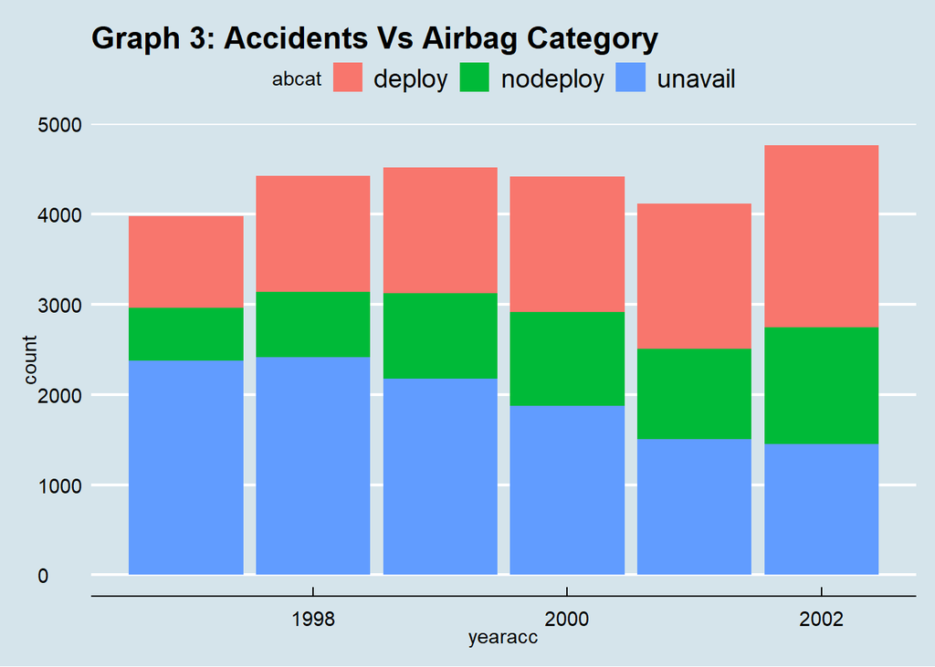

```r
ggplot(data= df)+geom_bar(aes(yearacc, fill=abcat))+ggtitle("Graph 3: Accidents Vs Airbag Category")+theme_economist()
```

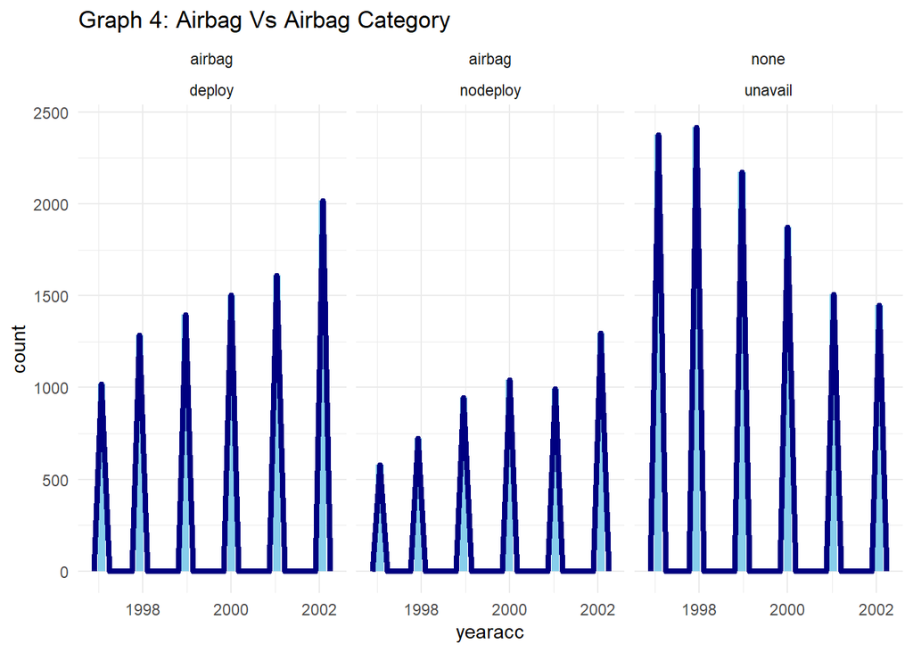

```r
ggplot(df) + aes(yearacc) + geom_histogram(fill='skyblue') + geom_freqpoly(color='navy', size = 1.5) +facet_wrap(~airbag~abcat)+theme_minimal()+ggtitle("Graph 4: Airbag Vs Airbag Category")
```

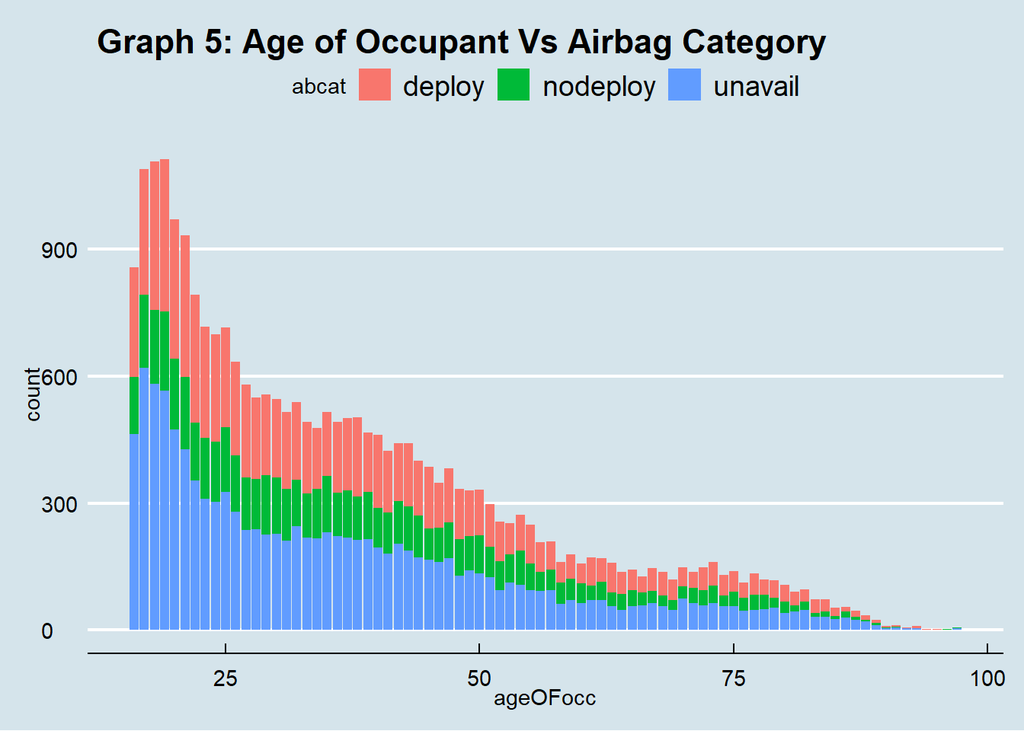

```r
ggplot(data= df)+geom_bar(aes(ageOFocc, fill=abcat))+ggtitle(" Graph 5: Age of Occupant Vs Airbag Category")+theme_economist()
```

#### We can see from the first graph, that till 1986, all the cars that were manufactured did not come with airbags. Post 1986, the cars that were manufactured came along with airbags and we can see that from 1997 onwards, almost all the cars were manufactured with airbags.

#### In the second graph we can see that, when comparing the number of fatalities with respect to vehicles having airbag or not, we can see that irrespective of the vehicle having an airbag or not, majority of the population have survived the accident though there is a slight increase in the number of fatalities in vehicles not having an airbag.

#### From graph 3, we can see that even if a car had an airbag, it was not always the case that the airbag was deployed. The accidents caused due to non-deployment of airbags have increased over the years.

#### In graph 4, we observe that when the airbags were unavailable, the accidents caused due to this was more. We can observe one strange trend here that when the cars had airbags and the airbags were deployed, the number of accidents were higher as compared to those cars where the airbags weren’t deployed. The people most at risk of death from airbag deployment are actually children and small adults, because their bodies can’t take the force. Moreover, most children ride in child safety seats, which aren’t designed for use with airbags. Seat type and positioning can also put a child at risk.

# Seatbelt Vs Fatalities

```r
xtabs(~seatbelt + dead, data=df)
```

```
##         dead
## seatbelt alive  dead
##   belted 18073   500
##   none    6964   680
```

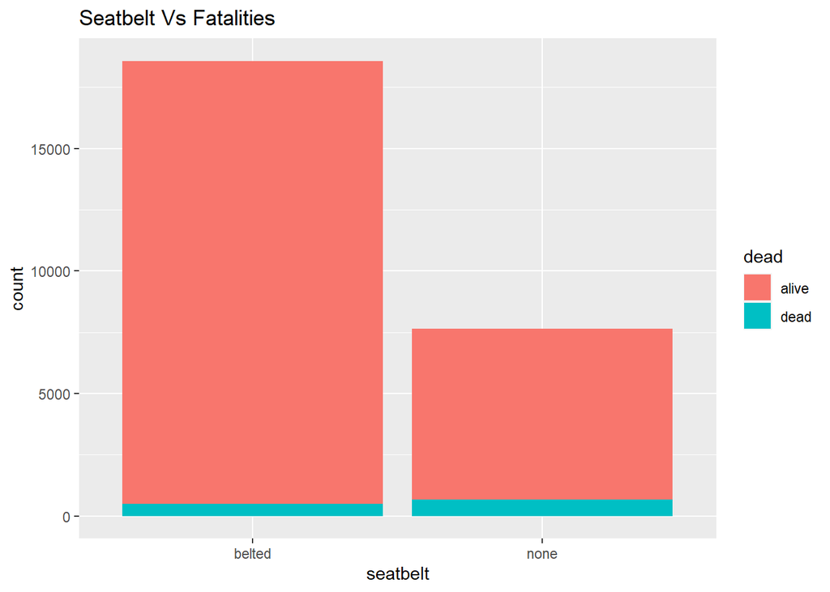

```r
ggplot()+geom_bar(data= df,aes(seatbelt, fill=dead))+ggtitle("Seatbelt Vs Fatalities")
```

# Speed Vs Fatalities

```r
xtabs(~speed + dead, data=df)
```

```
##          dead
## speed     alive  dead
##   1-9km/h   683     3
##   10-24   12734   114
##   25-39    7910   304
##   40-54    2633   344
##   55+      1077   415
```

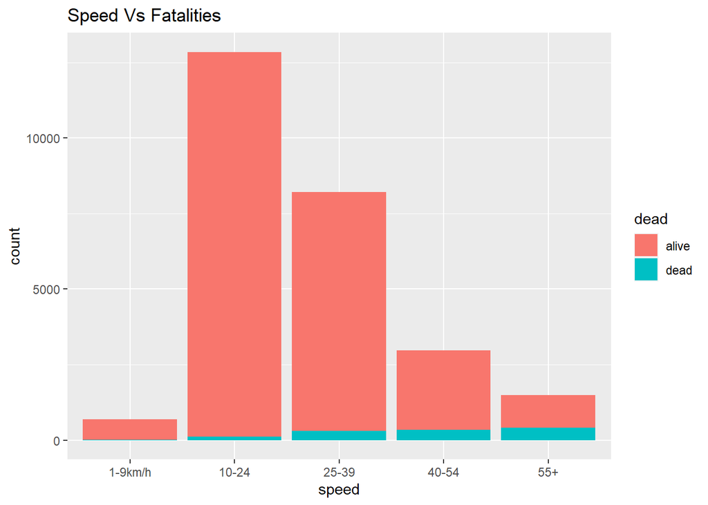

```r
ggplot()+geom_bar(data= df,aes(speed, fill=dead))+ggtitle("Speed Vs Fatalities")
```

#### We can see that the maximum deaths have happened when the speed of the car was more. So, lesser the speed, higher is the chance of survival.

# Speed Vs Injury Severity

```r
df$injsev[df$injSeverity==0] <- "None"
df$injsev[df$injSeverity==1] <- "Possible Injury"
df$injsev[df$injSeverity==2] <- "No incapacity"
df$injsev[df$injSeverity==3] <- "Incapacity"
df$injsev[df$injSeverity==4] <- "Killed"
df$injsev[df$injSeverity==5] <- "Unknown"
df$injsev[df$injSeverity==6] <- "Prior death"
head(df)
```

```
##   X speed  dead airbag seatbelt frontal sex ageOFocc yearacc yearVeh   abcat
## 1 1 25-39 alive   none   belted       1   f       26    1997    1990 unavail
## 2 2 10-24 alive airbag   belted       1   f       72    1997    1995  deploy
## 3 3 10-24 alive   none     none       1   f       69    1997    1988 unavail
## 4 4 25-39 alive airbag   belted       1   f       53    1997    1995  deploy
## 5 5 25-39 alive   none   belted       1   f       32    1997    1988 unavail
## 6 6 40-54 alive   none   belted       1   f       22    1997    1985 unavail
##   occRole deploy injSeverity X.1 X.2          injsev
## 1  driver      0           3  NA  NA      Incapacity
## 2  driver      1           1  NA  NA Possible Injury
## 3  driver      0           4  NA  NA          Killed
## 4  driver      1           1  NA  NA Possible Injury
## 5  driver      0           3  NA  NA      Incapacity
## 6  driver      0           3  NA  NA      Incapacity
```

```r
table1<-table(df$injsev,df$speed)
table1
```

```
##
##                   1-9km/h 10-24 25-39 40-54  55+
##   Incapacity           90  2817  3220  1536  832
##   Killed                4   111   278   329  396
##   No incapacity        65  1863  1623   548  143
##   None                366  4530  1365   185   33
##   Possible Injury     144  3377  1642   352   80
##   Prior death           0     1     1     0    0
##   Unknown               7    68    36    15    7
```

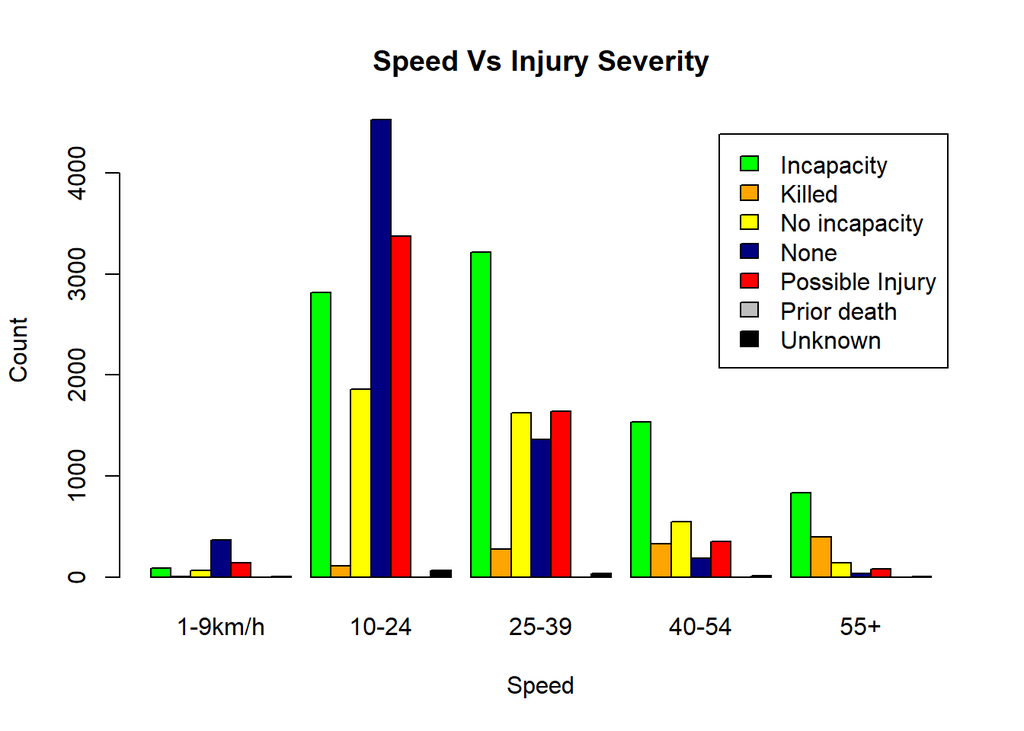

```r
barplot(table1,main = "Speed Vs Injury Severity",xlab ="Speed",ylab = "Count",col = c("green","orange","yellow","navy","red","gray","black"),legend=rownames(table1),beside = TRUE)
```

#### From this graph we can see that even though the speed is less, the person is still at risk of injury. As expected, as the speed increases, the number of people who die increases. Its surprising to see that at higher speeds, the number of people who are likely to suffer from an injury or are affected mentally or physically, reduces.

# Gender Vs Occupant Role

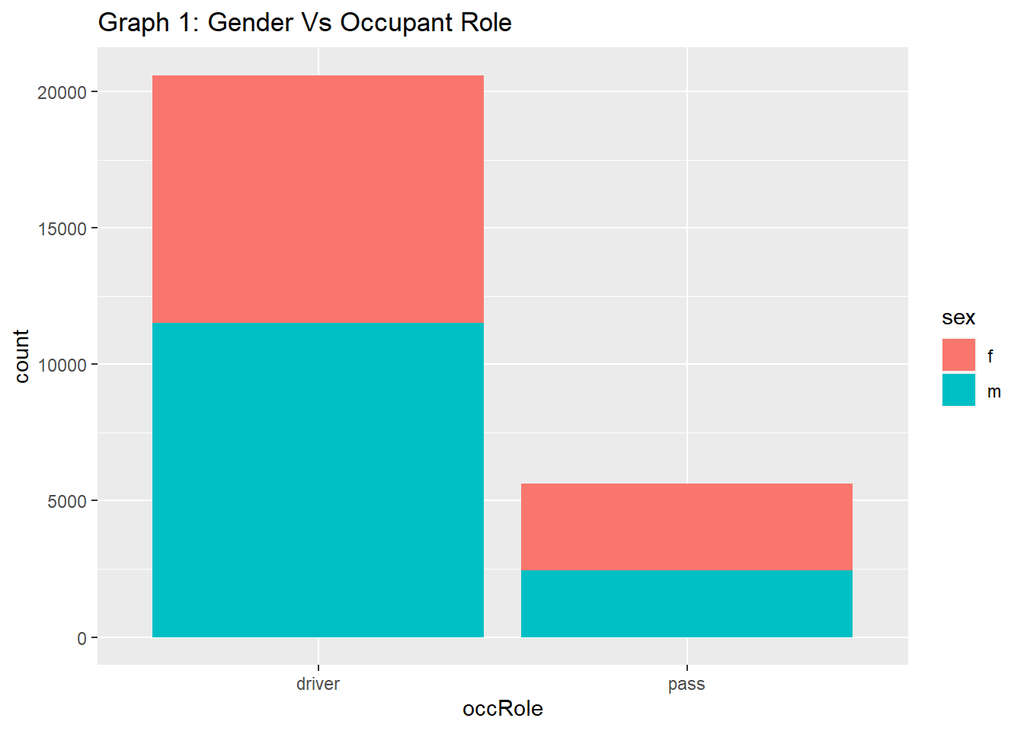

```r
ggplot(data= df)+geom_bar(aes(occRole, fill=sex))+ggtitle("Graph 1: Gender Vs Occupant Role")
```

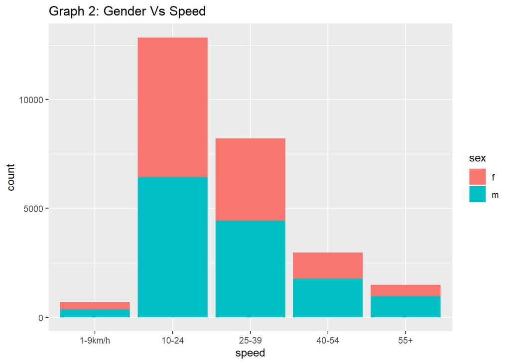

```r
ggplot(data= df)+geom_bar(aes(speed, fill=sex))+ggtitle("Graph 2: Gender Vs Speed")
```

#### In graph 1 we can observe that there are more male drivers than female drivers.

#### In graph 2 we can also notice that female drivers prefer to drive slower (within the speed limit) than male drivers. As a higher number of male drivers drive at speeds greater than 55 km/h.

#### We had assumed that a seatbelt can reduce the fatalities which is confirmed with this graph that shows that people wearning belts have a higher survival rate that people without them.

# CONCLUSION